# Lab 2.2

Author

Eric Lim

Published

February 23, 2023

# 1 Lab-2.2: Tableau

**Instructions**

- Read and work through all tutorial content on the `Tableau` page, under the `slides` tab, on the course website.
- Also complete the following assignment below
  - Click here to download the notebook
- The data for the assignment is in the file `mpg.xlsx`

**Submission:**

- You need to upload ONE document to Canvas when you are done
  - 1. An HTML (or PDF) version of the completed form of this notebook
- All outputs must be visible in the uploaded version, including code-cell outputs, images, graphs, etc
- i.e. replace the provided plots, with your plots, and then render to HTML.
- The file should be “self contained”, meaning no external dependencies are needed.

### 1.0.1 Lab-2.2.1: Create a worksheet

- Re-create the following image generated using Tableau, do not use any other visualization tools.
- The image should be more or less identical
- However, **you must use a different color pallet** than shown in the provided image.
- To save the image, click the `Workspace` tab and select `Export --> image`

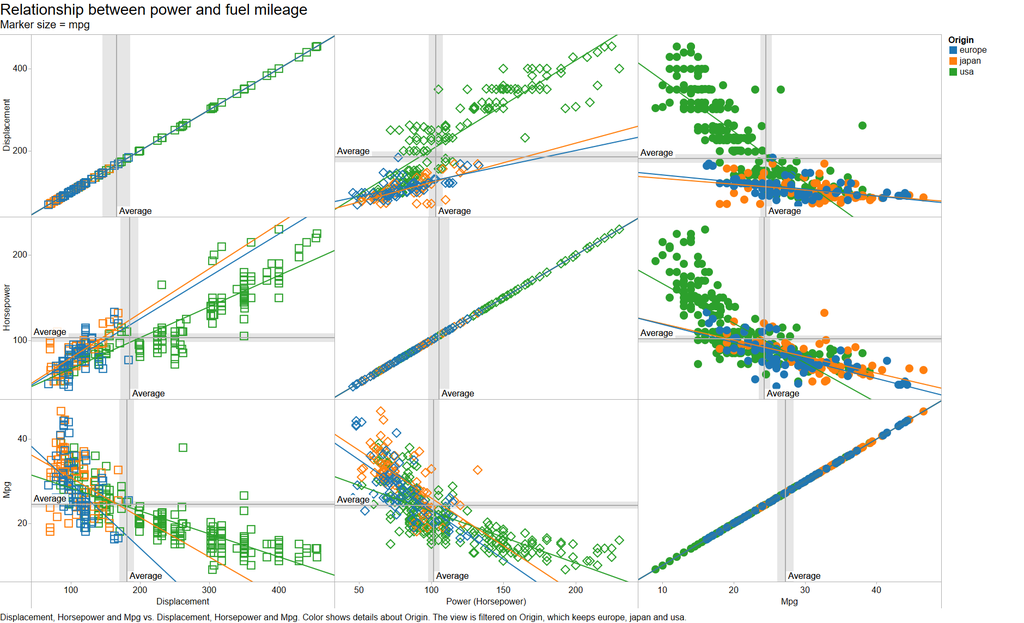

### 1.0.2 Lab-2.2.2: Create a dashboard

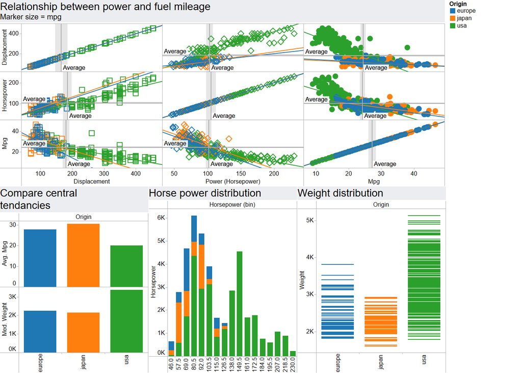

### 1.0.3 Lab-2.2.3: Dashboard Filtering

- Re-create the following dashboard generated using Tableau, do not use any other visualization tools. You can filter the previous dashboard to get this effect.
- The image should be more or less identical
- However, **you must use a different color pallet** than shown in the provided image.

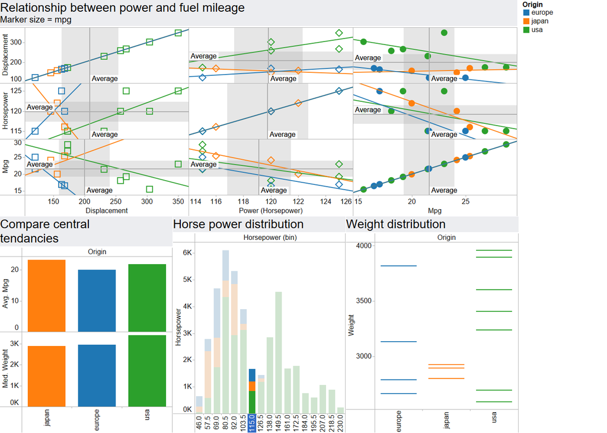

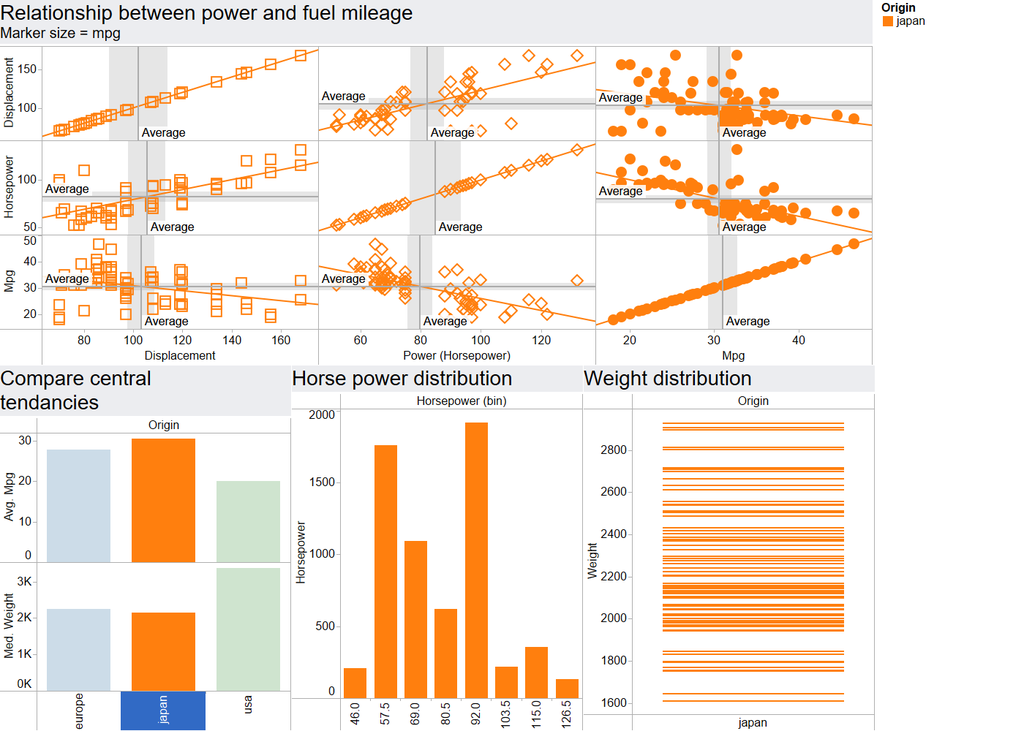